# Peltier and Thermistor Testing 10-29-2022

# Overview

The goal of this code is to analyze the differences between temperature readings of the Peltier inside of the magnetic field and outside of the magnetic field. For this trial, the magnetic field conditions were as follows:

V = 6.2 Volts I = 2.42 Amps

These trials were performed with the “peltiercontrolwiththerm” Arduino code which took the starting temperature of the Peltier and calculated the voltage needed to be applied in order to get to the target temperature of 37 degrees C. Because the starting temperature of the Arduino was not always consistent, the voltage applied to the peltier was inconsistent. I believe that this contributed to the significnat temperature swings that I observed but let’s see if this is supported statistically.

```r
# clear the environment window
rm(list = ls())

# import the libraries that we will need
library(ggplot2)
library(dplyr)
library(here)
```

Now I will import the data that I took from those trials. The data is separated into trials and consists all of temperatures calculated in degrees C. - Ex:t1_o referring to trial 1 out of magnetic field - Ex:t3_m referring to trial 3 inside of magnetic field

```r
# import the data and call it temp
temp <- read.csv(here("Data", "Peltiertempanalysis10-28.csv"))

# open the data in a new window to take a look at it
View(temp)
```

To compare the average means between the magnetic field and non magnetic field conditions, we can perform a two sample t test. This will give us a quick look at the differences between the two conditions

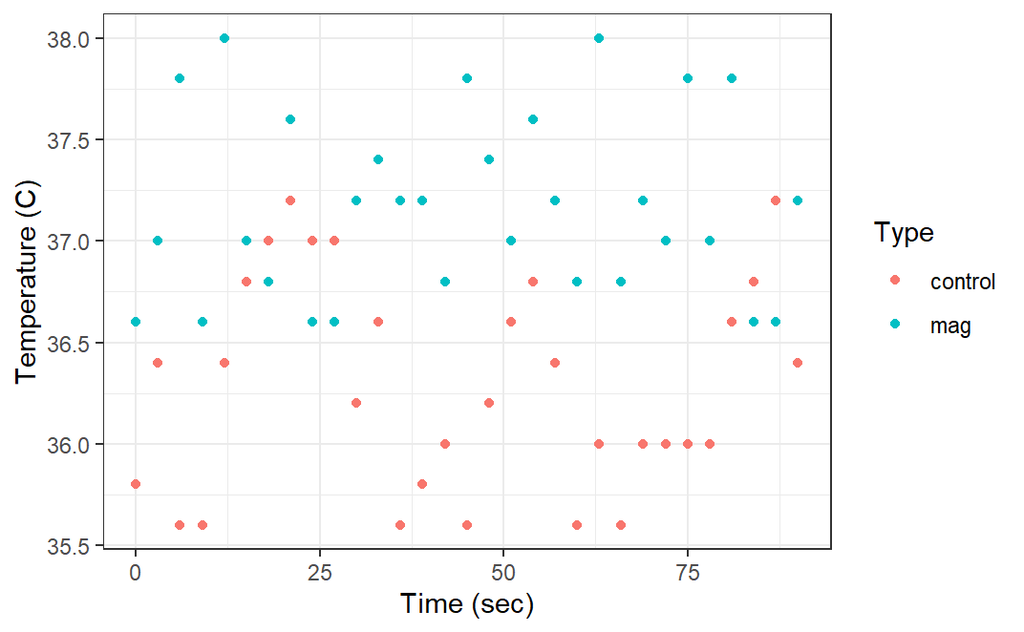

```r
# plot a scatter plot that will give us an idea of the differences between the two conditions

ggplot(temp,
       aes(x = Time_sec, y = Avg, colour = Type))+
     geom_point()+
     xlab("Time (sec)")+
     ylab("Temperature (C)")+
     theme_bw()
```

Upon first glance, it looks like there may be a difference between the conditions in the magnetic field and outside of the magnetic field. Let’s perform a two sample t test to find out.

```r
# perform two sample t test
t.test(Avg ~ Type, data = temp)
```

```
    Welch Two Sample t-test

data:  Avg by Type
t = -7.1455, df = 58.775, p-value = 1.563e-09
alternative hypothesis: true difference in means between group control and group mag is not equal to 0
95 percent confidence interval:
 -1.1314061 -0.6363358
sample estimates:
mean in group control     mean in group mag
             36.28387              37.16774
```